# Different Gene Expression Analysis

Sahiti K

# Abstract

Differential gene expression analysis identifies genes that are significantly up regulated or down regulated between experimental conditions. This report analyzes a published dataset, classifies genes based on fold change and p-value thresholds, and visualizes results using a volcano plot.  
The top regulated genes are summarized in a tabular format to highlight potential biological significance.

# Workflow

### 1. Load Data

Read the file from the given URL. It is white space-separated, so we set `sep = ""`.

```r
data <- read.table(
  "https://gist.githubusercontent.com/stephenturner/806e31fce55a8b7175af/raw/1a507c4c3f9f1baaa3a69187223ff3d3050628d4/results.txt",
  header = TRUE,
  sep = "",
  stringsAsFactors = FALSE
)

# Inspect structure and first few rows
str(data)
```

```
## 'data.frame':    16406 obs. of  4 variables:
##  $ Gene          : chr  "DOK6" "TBX5" "SLC32A1" "IFITM1" ...
##  $ log2FoldChange: num  0.51 -2.129 0.9 -1.687 0.366 ...
##  $ pvalue        : num  1.86e-08 5.66e-08 7.66e-08 3.73e-06 3.37e-06 ...
##  $ padj          : num  0.000305 0.000419 0.000419 0.006809 0.006809 ...
```

```r
head(data)
```

```
##      Gene log2FoldChange    pvalue      padj
## 1    DOK6         0.5100 1.861e-08 0.0003053
## 2    TBX5        -2.1290 5.655e-08 0.0004191
## 3 SLC32A1         0.9003 7.664e-08 0.0004191
## 4  IFITM1        -1.6870 3.735e-06 0.0068090
## 5   NUP93         0.3659 3.373e-06 0.0068090
## 6 EMILIN2         1.5340 2.976e-06 0.0068090
```

### 2. Add Derived Columns

- Compute `-log10(pvalue)` for volcano plot.
- Transform p-values to –log₁₀(p) to amplify significance, making key genes stand out at the top of the volcano plot.
- Add a classification column (`Up`, `Down`, or `Not Significant`).

```r
data$logP <- -log10(data$pvalue)

# Default classification
data$status <- "Not Significant"
data$status[data$log2FoldChange > 1 & data$pvalue < 0.01] <- "Up"
data$status[data$log2FoldChange < -1 & data$pvalue < 0.01] <- "Down"

head(data)
```

```
##      Gene log2FoldChange    pvalue      padj     logP          status
## 1    DOK6         0.5100 1.861e-08 0.0003053 7.730254 Not Significant
## 2    TBX5        -2.1290 5.655e-08 0.0004191 7.247567            Down
## 3 SLC32A1         0.9003 7.664e-08 0.0004191 7.115545 Not Significant
## 4  IFITM1        -1.6870 3.735e-06 0.0068090 5.427709            Down
## 5   NUP93         0.3659 3.373e-06 0.0068090 5.471984 Not Significant
## 6 EMILIN2         1.5340 2.976e-06 0.0068090 5.526367              Up
```

### 3. Save Updated Tables

```r
# Save all genes
write.csv(data, "classified_gene_expression.csv", row.names = FALSE)

# Save only significant genes
sig_data <- subset(data, status != "Not Significant")
write.csv(sig_data, "significant_genes.csv", row.names = FALSE)
```

# Results

## 4. Volcano Plot

Significant genes highlighted in **red** (Up), **blue** (Down), and grey otherwise.

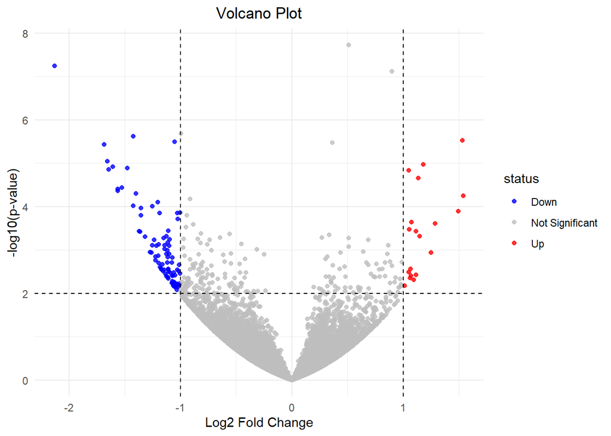

```r
# 3. Volcano plot
volcano_plot <- ggplot(data, aes(x = log2FoldChange, y = logP, color = status)) +
  geom_point(alpha = 0.8) +
  scale_color_manual(values = c("blue", "grey", "red")) +
  geom_vline(xintercept = c(-1, 1), linetype = "dashed") +
  geom_hline(yintercept = -log10(0.01), linetype = "dashed") +
  theme_minimal() +
  labs(
    title = "Volcano Plot",
    x = "Log2 Fold Change",
    y = "-log10(p-value)"
  ) +
  theme(
    plot.title = element_text(hjust = 0.5)  # Center the title
  )

volcano_plot
```

```r
# Save with white background
ggsave("volcano_plot.png", volcano_plot, width = 7, height = 5, bg = "white")
```

## 5. Top Genes Summary Table

We extract the **top 5 up regulated** and **top 5 down regulated** genes.

```r
# Filter
up_genes <- subset(data, log2FoldChange > 1 & pvalue < 0.01)
down_genes <- subset(data, log2FoldChange < -1 & pvalue < 0.01)

# Sort
# Top 5 upregulated genes (largest positive log2FC)
top5_up <- head(up_genes[order(-up_genes$log2FoldChange), ], 5)

# Top 5 downregulated genes (most negative log2FC)
top5_down <- head(down_genes[order(down_genes$log2FoldChange), ], 5)

# Create summary
summary_table <- data.frame(
  Upregulated_Gene = top5_up$Gene,
  Up_Log2FC = round(top5_up$log2FoldChange, 3),
  Up_Pvalue = signif(top5_up$pvalue, 3),
  Downregulated_Gene = top5_down$Gene,
  Down_Log2FC = round(top5_down$log2FoldChange, 3),
  Down_Pvalue = signif(top5_down$pvalue, 3)
)

# Make a table with a title
knitr::kable(summary_table, caption = "Top 5 Upregulated and Downregulated Genes")
```

Top 5 Upregulated and Downregulated Genes

| Upregulated_Gene | Up_Log2FC | Up_Pvalue | Downregulated_Gene | Down_Log2FC | Down_Pvalue |
| --- | --- | --- | --- | --- | --- |
| DTHD1 | 1.540 | 5.59e-05 | TBX5 | -2.129 | 1.00e-07 |
| EMILIN2 | 1.534 | 3.00e-06 | IFITM1 | -1.687 | 3.70e-06 |
| PI16 | 1.495 | 1.30e-04 | TNN | -1.658 | 9.00e-06 |
| C4orf45 | 1.288 | 2.47e-04 | COL13A1 | -1.647 | 1.39e-05 |
| FAM180B | 1.249 | 1.15e-03 | IFITM3 | -1.610 | 1.20e-05 |

```r
# Save to file
write.csv(summary_table, "summary_table.csv", row.names = FALSE)
```

# Discussion

The biological significance of the top genes, interpreted using **GeneCards**.

## Up regulated genes

**Functional summary of top 5 upregulated genes**

| Genes | Functions |
| --- | --- |
| DTHD1 | Encodes a protein with a death domain; Involved in signaling and apoptosis pathways. |
| EMILIN2 | Extracellular matrix protein; promotes angiogenesis, defense response, and platelet aggregation. |
| PI16 | Peptidase inhibitor; regulates cardiac muscle cell growth; active in extracellular space. |
| C4orf45 | Also known as SPMIP2; associated with Hyperekplexia; sperm microtubule inner protein. |
| FAM180B | Predicted to be located in the extracellular region. |

## Down regulated genes

**Functional summary of top 5 downregulated genes**

| Genes | Functions |
| --- | --- |
| TBX5 | T-box transcription factor; key role in heart and limb development; linked to Holt-Oram syndrome. |
| IFITM1 | Interferon-induced antiviral protein; blocks viral entry (e.g., influenza, Ebola, SARS-CoV-2 |
| TNN | Integrin-binding protein; regulates angiogenesis, cell adhesion, and migration |
| COL13A1 | Nonfibrillar collagen with transmembrane domain; may support general connective tissue function. |
| IFITM3 | Interferon-induced antiviral protein; restricts viral entry across multiple pathogens. |

These functional annotations provide biological meaning to the statistical findings and help generate hypotheses for further laboratory validation.